# I ) Data preparation & exploration:

# A. Problem statement

- The data set: clients of Delta Bank.
- Data for each client: Attrition_Flag, Customer_Age, Gender, Dependent_count, Education_Level, Marital_Status, Income_Category, Card_Category, Months_on_book, Total_Relationship_Count, Months_Inactive_12_mon, Contacts_Count_12_mon, Credit_Limit, Total_Used_Bal, Total_Unused_Bal, Total_Amt_Chng_Q4_Q1, Total_Trans_Amt, Total_Trans_Ct, Total_Ct_Chng_Q4_Q1 and Avg_Utilization_Ratio.
- Objective: Find the most probable clients that will leave the company.

# B. Import libraries

```python
import numpy as np
import pandas as pd
import matplotlib.pyplot as plt
import missingno as msno
import seaborn as sns
```

# C. Read dataset

```python
path = 'C:\\Users\\teodo\\Desktop\\BCR\\TTJ project\\dataset\\dataset.csv'
```

```python
data = pd.read_csv(path)
```

# D. Exploratory data analysis

## 1. General

### a) View dimensions of dataset

```python
data.shape
```

```
(10127, 21)
```

### b) Preview of dataset

```python
data.head(100)
```

|  | CLIENTNUM | Attrition_Flag | Customer_Age | Gender | Dependent_count | Education_Level | Marital_Status | Income_Category | Card_Category | Months_on_book | ... | Months_Inactive_12_mon | Contacts_Count_12_mon | Credit_Limit | Total_Used_Bal | Total_Unused_Bal | Total_Amt_Chng_Q4_Q1 | Total_Trans_Amt | Total_Trans_Ct | Total_Ct_Chng_Q4_Q1 | Avg_Utilization_Ratio |
| --- | --- | --- | --- | --- | --- | --- | --- | --- | --- | --- | --- | --- | --- | --- | --- | --- | --- | --- | --- | --- | --- |
| 0 | 768805383 | Existing Customer | 45.0 | M | 3.0 | High School | Married | $60K - $80K | Blue | 39 | ... | 1 | 3 | 12691.0 | 777 | 11914.0 | 1.335 | 1144 | 42 | 1.625 | 0.061 |
| 1 | 818770008 | Existing Customer | 49.0 | F | 5.0 | Graduate | Single | Less than $40K | Blue | 44 | ... | 1 | 2 | 8256.0 | 864 | 7392.0 | 1.541 | 1291 | 33 | 3.714 | 0.105 |
| 2 | 713982108 | Existing Customer | 51.0 | M | 3.0 | Graduate | Married | $80K - $120K | Blue | 36 | ... | 1 | 0 | 3418.0 | 0 | 3418.0 | 2.594 | 1887 | 20 | 2.333 | 0.000 |
| 3 | 769911858 | Existing Customer | 40.0 | F | 4.0 | High School | NaN | Less than $40K | Blue | 34 | ... | 4 | 1 | 3313.0 | 2517 | 796.0 | 1.405 | 1171 | 20 | 2.333 | 0.760 |
| 4 | 709106358 | Existing Customer | 40.0 | M | 3.0 | Uneducated | Married | $60K - $80K | Blue | 21 | ... | 1 | 0 | 4716.0 | 0 | 4716.0 | 2.175 | 816 | 28 | 2.500 | 0.000 |
| ... | ... | ... | ... | ... | ... | ... | ... | ... | ... | ... | ... | ... | ... | ... | ... | ... | ... | ... | ... | ... | ... |
| 95 | 719712633 | Existing Customer | 64.0 | M | 1.0 | Graduate | Married | Less than $40K | Blue | 52 | ... | 4 | 3 | 1709.0 | 895 | 814.0 | 1.656 | 1673 | 32 | 0.882 | 0.524 |
| 96 | 772629333 | Existing Customer | 45.0 | M | 3.0 | Graduate | Married | $40K - $60K | Blue | 35 | ... | 4 | 2 | 3454.0 | 1200 | 2254.0 | 0.597 | 1313 | 30 | 0.304 | 0.347 |
| 97 | 720336708 | Existing Customer | 53.0 | M | 3.0 | Doctorate | Married | $40K - $60K | Blue | 35 | ... | 3 | 2 | 3789.0 | 1706 | 2083.0 | 1.047 | 1609 | 42 | 0.680 | 0.450 |
| 98 | 802013583 | Existing Customer | 56.0 | M | 3.0 | College | Married | $120K + | Blue | 50 | ... | 2 | 0 | 9689.0 | 2250 | 7439.0 | 0.576 | 1158 | 19 | 0.727 | 0.232 |
| 99 | 711887583 | Attrited Customer | 47.0 | M | 2.0 | NaN | Married | $80K - $120K | Blue | 37 | ... | 3 | 3 | 5449.0 | 1628 | 3821.0 | 0.696 | 836 | 18 | 0.385 | 0.299 |

100 rows × 21 columns

### c) View column names

```python
columns = data.columns
print(columns)
```

```
Index(['CLIENTNUM', 'Attrition_Flag', 'Customer_Age', 'Gender',
       'Dependent_count', 'Education_Level', 'Marital_Status',
       'Income_Category', 'Card_Category', 'Months_on_book',
       'Total_Relationship_Count', 'Months_Inactive_12_mon',
       'Contacts_Count_12_mon', 'Credit_Limit', 'Total_Used_Bal',
       'Total_Unused_Bal', 'Total_Amt_Chng_Q4_Q1', 'Total_Trans_Amt',
       'Total_Trans_Ct', 'Total_Ct_Chng_Q4_Q1', 'Avg_Utilization_Ratio'],
      dtype='object')
```

### d) View types of columns

```python
data.dtypes
```

```
CLIENTNUM                     int64
Attrition_Flag               object
Customer_Age                float64
Gender                       object
Dependent_count             float64
Education_Level              object
Marital_Status               object
Income_Category              object
Card_Category                object
Months_on_book                int64
Total_Relationship_Count      int64
Months_Inactive_12_mon        int64
Contacts_Count_12_mon         int64
Credit_Limit                float64
Total_Used_Bal                int64
Total_Unused_Bal            float64
Total_Amt_Chng_Q4_Q1        float64
Total_Trans_Amt               int64
Total_Trans_Ct                int64
Total_Ct_Chng_Q4_Q1         float64
Avg_Utilization_Ratio       float64
dtype: object
```

### e) View information about dataset

```python
data.info()
```

```
<class 'pandas.core.frame.DataFrame'>
RangeIndex: 10127 entries, 0 to 10126
Data columns (total 21 columns):
 #   Column                    Non-Null Count  Dtype
---  ------                    --------------  -----
 0   CLIENTNUM                 10127 non-null  int64
 1   Attrition_Flag            10127 non-null  object
 2   Customer_Age              10124 non-null  float64
 3   Gender                    10127 non-null  object
 4   Dependent_count           10122 non-null  float64
 5   Education_Level           8608 non-null   object
 6   Marital_Status            9378 non-null   object
 7   Income_Category           10125 non-null  object
 8   Card_Category             10127 non-null  object
 9   Months_on_book            10127 non-null  int64
 10  Total_Relationship_Count  10127 non-null  int64
 11  Months_Inactive_12_mon    10127 non-null  int64
 12  Contacts_Count_12_mon     10127 non-null  int64
 13  Credit_Limit              10127 non-null  float64
 14  Total_Used_Bal            10127 non-null  int64
 15  Total_Unused_Bal          10127 non-null  float64
 16  Total_Amt_Chng_Q4_Q1      10127 non-null  float64
 17  Total_Trans_Amt           10127 non-null  int64
 18  Total_Trans_Ct            10127 non-null  int64
 19  Total_Ct_Chng_Q4_Q1       10127 non-null  float64
 20  Avg_Utilization_Ratio     10127 non-null  float64
dtypes: float64(7), int64(8), object(6)
memory usage: 1.6+ MB
```

#### Comment: Avem variabile atat numerice ( int, float ) cat si categorice ( object )

### f) View statistical properties of dataset

- For numerical variables:

```python
data.describe()
```

|  | CLIENTNUM | Customer_Age | Dependent_count | Months_on_book | Total_Relationship_Count | Months_Inactive_12_mon | Contacts_Count_12_mon | Credit_Limit | Total_Used_Bal | Total_Unused_Bal | Total_Amt_Chng_Q4_Q1 | Total_Trans_Amt | Total_Trans_Ct | Total_Ct_Chng_Q4_Q1 | Avg_Utilization_Ratio |
| --- | --- | --- | --- | --- | --- | --- | --- | --- | --- | --- | --- | --- | --- | --- | --- |
| count | 1.012700e+04 | 10124.000000 | 10122.000000 | 10127.000000 | 10127.000000 | 10127.000000 | 10127.000000 | 10127.000000 | 10127.000000 | 10127.000000 | 10127.000000 | 10127.000000 | 10127.000000 | 10127.000000 | 10127.000000 |
| mean | 7.391776e+08 | 46.326057 | 2.345781 | 35.928409 | 3.812580 | 2.341167 | 2.455317 | 8631.953698 | 1162.814061 | 7469.139637 | 0.759941 | 4404.086304 | 64.858695 | 0.712222 | 0.274894 |
| std | 3.690378e+07 | 8.017889 | 1.298908 | 7.986416 | 1.554408 | 1.010622 | 1.106225 | 9088.776650 | 814.987335 | 9090.685324 | 0.219207 | 3397.129254 | 23.472570 | 0.238086 | 0.275691 |
| min | 7.080821e+08 | 26.000000 | 0.000000 | 13.000000 | 1.000000 | 0.000000 | 0.000000 | 1438.300000 | 0.000000 | 3.000000 | 0.000000 | 510.000000 | 10.000000 | 0.000000 | 0.000000 |
| 25% | 7.130368e+08 | 41.000000 | 1.000000 | 31.000000 | 3.000000 | 2.000000 | 2.000000 | 2555.000000 | 359.000000 | 1324.500000 | 0.631000 | 2155.500000 | 45.000000 | 0.582000 | 0.023000 |
| 50% | 7.179264e+08 | 46.000000 | 2.000000 | 36.000000 | 4.000000 | 2.000000 | 2.000000 | 4549.000000 | 1276.000000 | 3474.000000 | 0.736000 | 3899.000000 | 67.000000 | 0.702000 | 0.176000 |
| 75% | 7.731435e+08 | 52.000000 | 3.000000 | 40.000000 | 5.000000 | 3.000000 | 3.000000 | 11067.500000 | 1784.000000 | 9859.000000 | 0.859000 | 4741.000000 | 81.000000 | 0.818000 | 0.503000 |
| max | 8.283431e+08 | 73.000000 | 5.000000 | 56.000000 | 6.000000 | 6.000000 | 6.000000 | 34516.000000 | 2517.000000 | 34516.000000 | 3.397000 | 18484.000000 | 139.000000 | 3.714000 | 0.999000 |

- For categorical variables

```python
data.describe(include = ['object'])
```

|  | Attrition_Flag | Gender | Education_Level | Marital_Status | Income_Category | Card_Category |
| --- | --- | --- | --- | --- | --- | --- |
| count | 10127 | 10127 | 8608 | 9378 | 10125 | 10127 |
| unique | 2 | 2 | 6 | 3 | 6 | 4 |
| top | Existing Customer | F | Graduate | Married | Less than $40K | Blue |
| freq | 8500 | 5358 | 3128 | 4687 | 3560 | 9436 |

## 2. Univariate analysis

### We want to analyze our target variable ('Attrition_Flag')

### a) Check if variable has missing values

```python
data['Attrition_Flag'].isnull().sum()
```

```
0
```

### b) View unique values

```python
data['Attrition_Flag'].nunique()
```

```
2
```

```python
data['Attrition_Flag'].unique()
```

```
array(['Existing Customer', 'Attrited Customer'], dtype=object)
```

### c) View frequency of values and percentaje of frequency

```python
data['Attrition_Flag'].value_counts()
```

```
Existing Customer    8500
Attrited Customer    1627
Name: Attrition_Flag, dtype: int64
```

```python
data['Attrition_Flag'].value_counts()/len(data) * 100
```

```
Existing Customer    83.934038
Attrited Customer    16.065962
Name: Attrition_Flag, dtype: float64
```

#### Comment: 83,93% of clients are Existing Customers and 16,07% of clients are Attrited Customers.

### d) Visualize frequency distribution of variable 'Attrition_Flag'

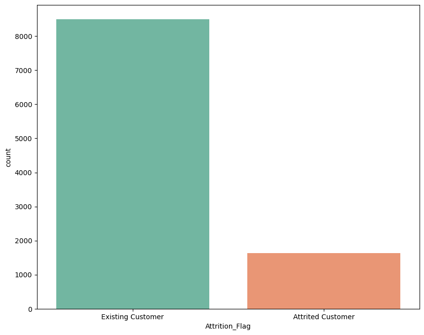

```python
fig, ax = plt.subplots(figsize=(10,8))
ax = sns.countplot(data = data, x = 'Attrition_Flag', palette = 'Set2')
plt.show()
```

### e) Change labels of variable 'Attrition_Flag' to numeric

```python
data['Attrition_Flag'] = data['Attrition_Flag'].map({'Existing Customer':0,'Attrited Customer':1})
```

```python
data['Attrition_Flag'].value_counts()
```

```
0    8500
1    1627
Name: Attrition_Flag, dtype: int64
```

## 3. Feature analysis

### 3.1 Categorical variables

#### a) Explore categorical variables

- Find categorical variables

```python
data.dtypes
```

```
CLIENTNUM                     int64
Attrition_Flag                int64
Customer_Age                float64
Gender                       object
Dependent_count             float64
Education_Level              object
Marital_Status               object
Income_Category              object
Card_Category                object
Months_on_book                int64
Total_Relationship_Count      int64
Months_Inactive_12_mon        int64
Contacts_Count_12_mon         int64
Credit_Limit                float64
Total_Used_Bal                int64
Total_Unused_Bal            float64
Total_Amt_Chng_Q4_Q1        float64
Total_Trans_Amt               int64
Total_Trans_Ct                int64
Total_Ct_Chng_Q4_Q1         float64
Avg_Utilization_Ratio       float64
dtype: object
```

- Select categorical variables

```python
categorical_columns = [col for col in data.columns if data[col].dtypes == 'object']
```

```python
print('There are',len(categorical_columns),'categorical variables. These are', categorical_columns)
```

```
There are 5 categorical variables. These are ['Gender', 'Education_Level', 'Marital_Status', 'Income_Category', 'Card_Category']
```

```python
data[categorical_columns].head()
```

|  | Gender | Education_Level | Marital_Status | Income_Category | Card_Category |
| --- | --- | --- | --- | --- | --- |
| 0 | M | High School | Married | $60K - $80K | Blue |
| 1 | F | Graduate | Single | Less than $40K | Blue |
| 2 | M | Graduate | Married | $80K - $120K | Blue |
| 3 | F | High School | NaN | Less than $40K | Blue |
| 4 | M | Uneducated | Married | $60K - $80K | Blue |

- Check distribution of variable 'Gender'

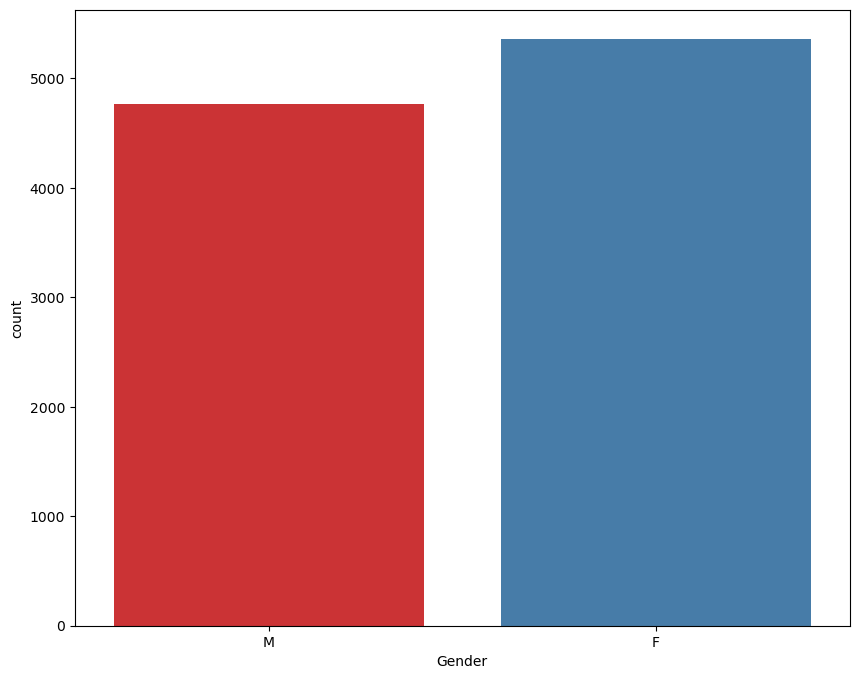

```python
fig, ax = plt.subplots(figsize = (10,8))
ax = sns.countplot(data = data, x = 'Gender', palette = 'Set1')
plt.show()
```

- Check distribution of variable 'Education_Level'

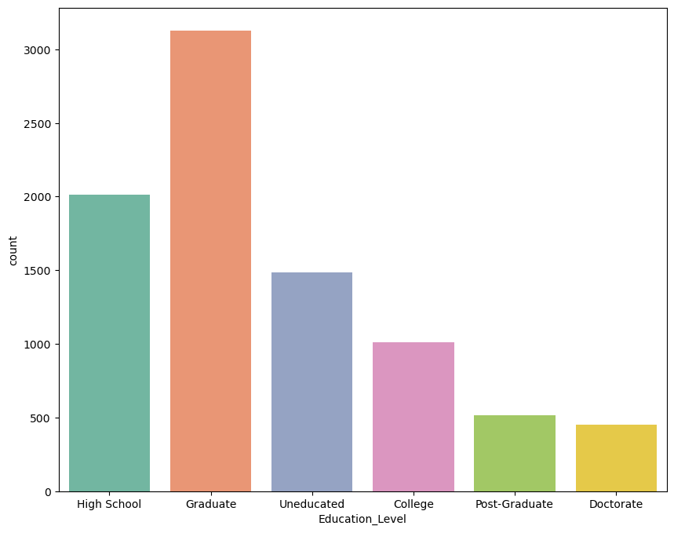

```python
fig, ax = plt.subplots(figsize = (10,8))
ax = sns.countplot(data = data, x = 'Education_Level', palette = 'Set2')
plt.show()
```

- Check distribution of variable 'Marital_Status'

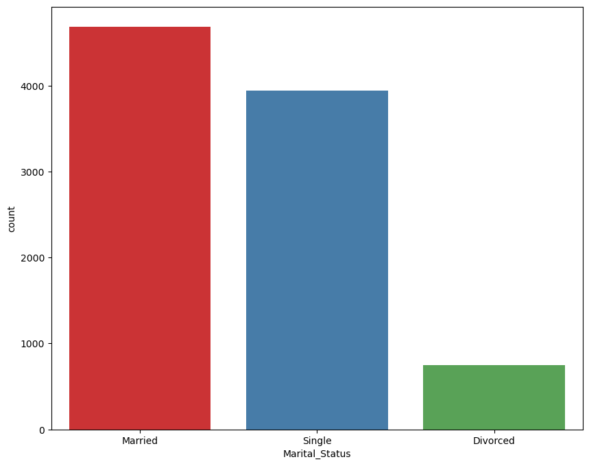

```python
fig, ax = plt.subplots(figsize = (10,8))
ax = sns.countplot(data = data, x = 'Marital_Status', palette = 'Set1')
plt.show()
```

- Check distribution of variable 'Income_Category'

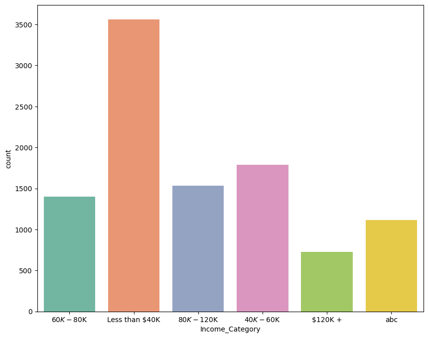

```python
fig, ax = plt.subplots(figsize = (10,8))
ax = sns.countplot(data = data, x = 'Income_Category', palette = 'Set2')
plt.show()
```

- Check distribution of variable 'Card_Category'

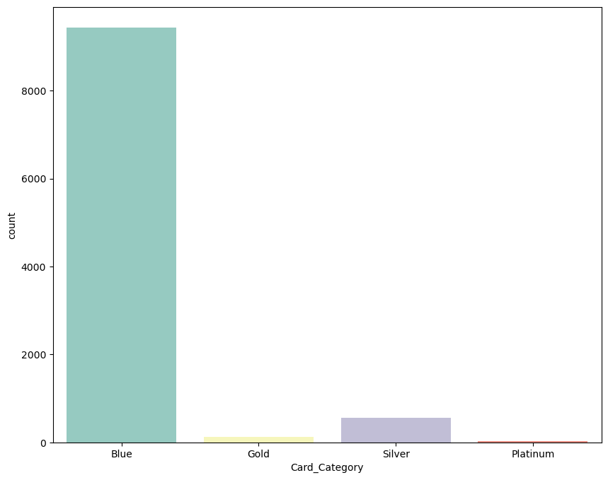

```python
fig, ax = plt.subplots(figsize = (10,8))
ax = sns.countplot(data = data, x = 'Card_Category', palette = 'Set3')
plt.show()
```

- Check distribution of categorical variables in relationship with target variable 'Attrition_Flag'

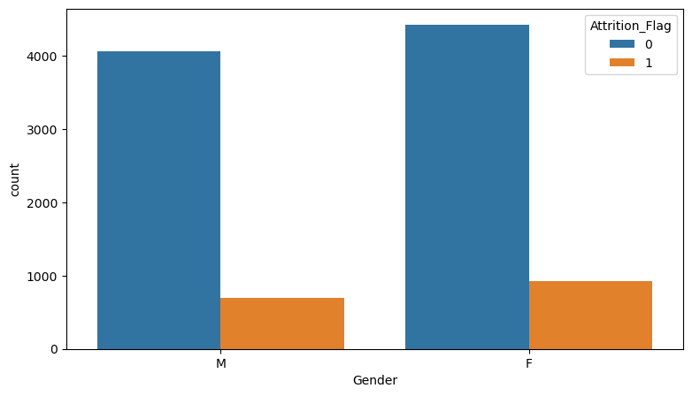

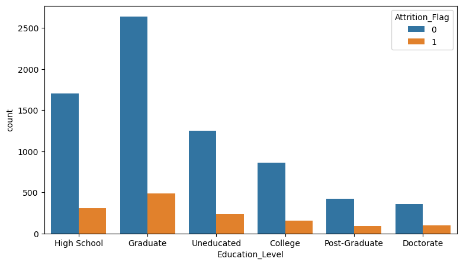

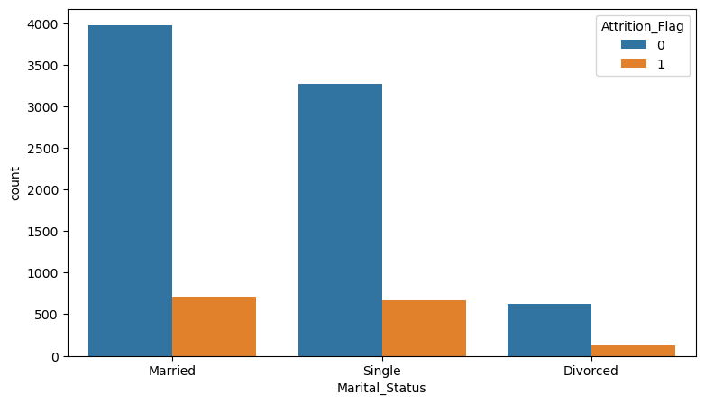

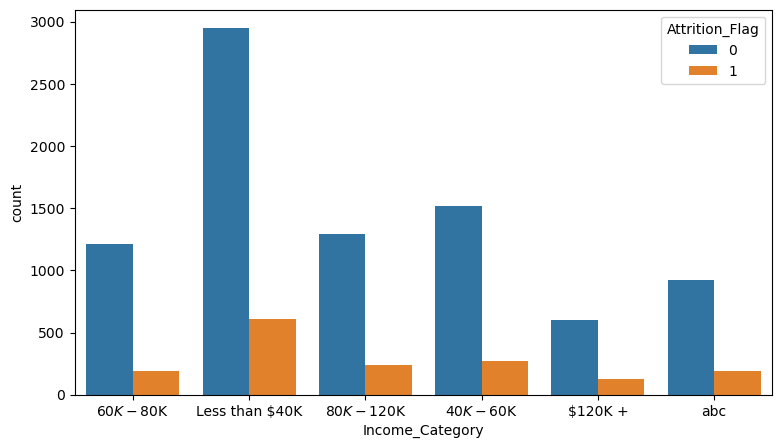

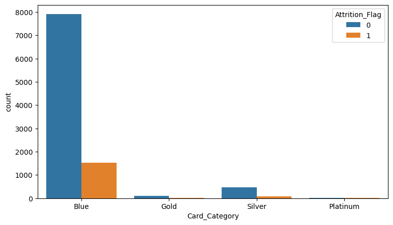

```python
for col in categorical_columns:
    fig, ax = plt.subplots(figsize = (9,5))
    ax = sns.countplot(data = data, x = col, hue = 'Attrition_Flag')
    plt.show()
```

#### b) Missing values imputaiton

- Check what categorical variables has missing values

```python
data[categorical_columns].isnull().sum()
```

```
Gender                0
Education_Level    1519
Marital_Status      749
Income_Category       2
Card_Category         0
dtype: int64
```

- Visualize missing values

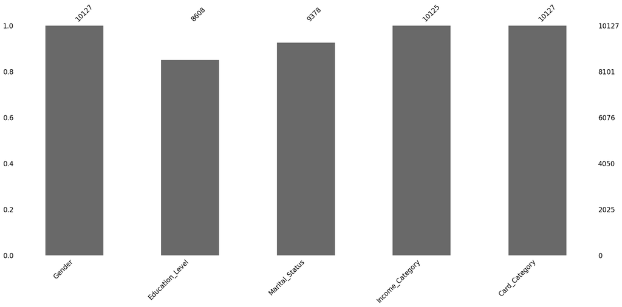

```python
msno.bar(data[categorical_columns])
```

- Education level

```python
data['Education_Level'].value_counts()
```

```
Graduate         3128
High School      2013
Uneducated       1487
College          1013
Post-Graduate     516
Doctorate         451
Name: Education_Level, dtype: int64
```

- Marital Status

```python
data['Marital_Status'].value_counts()
```

```
Married     4687
Single      3943
Divorced     748
Name: Marital_Status, dtype: int64
```

- Income Category

```python
data['Income_Category'].value_counts()
```

```
Less than $40K    3560
$40K - $60K       1789
$80K - $120K      1535
$60K - $80K       1402
abc               1112
$120K +            727
Name: Income_Category, dtype: int64
```

- Fill missing values

```python
data['Education_Level'] = data['Education_Level'].fillna('Unknown')
data['Marital_Status'] = data['Marital_Status'].fillna('Unknown')
data['Income_Category'] = data['Income_Category'].replace('abc','Unknown')
data['Income_Category'] = data['Income_Category'].fillna('Unknown')
```

```python
data[categorical_columns].isnull().sum()
```

```
Gender             0
Education_Level    0
Marital_Status     0
Income_Category    0
Card_Category      0
dtype: int64
```

#### c) Feature variance

```python
data[categorical_columns].nunique()
```

```
Gender             2
Education_Level    7
Marital_Status     4
Income_Category    6
Card_Category      4
dtype: int64
```

#### We do not have columns with an unique value so nothing has to be done in this case.

#### d) Categorical encoding

```python
data[categorical_columns].nunique()
```

```
Gender             2
Education_Level    7
Marital_Status     4
Income_Category    6
Card_Category      4
dtype: int64
```

- Education Level

```python
data['Education_Level'].value_counts()/len(data)*100
```

```
Graduate         30.887726
High School      19.877555
Unknown          14.999506
Uneducated       14.683519
College          10.002962
Post-Graduate     5.095290
Doctorate         4.453441
Name: Education_Level, dtype: float64
```

#### Comment: 30,89% of clients are graduates.

Encode for rare labels:

```python
values = data['Education_Level'].value_counts()/len(data)*100
```

```python
data['Education_Level'] = np.where(data['Education_Level'].isin(values.index[5:]), 'Post-Graduate / Doctorate', data['Education_Level'])
data['Education_Level'].value_counts()/len(data)*100
```

```
Graduate                     30.887726
High School                  19.877555
Unknown                      14.999506
Uneducated                   14.683519
College                      10.002962
Post-Graduate / Doctorate     9.548731
Name: Education_Level, dtype: float64
```

- Marital Status

```python
data['Marital_Status'].value_counts()/len(data)*100
```

```
Married     46.282216
Single      38.935519
Unknown      7.396070
Divorced     7.386195
Name: Marital_Status, dtype: float64
```

#### Comment: 46,28% of clients are married.

Encode for rare labels:

```python
values2 = data['Marital_Status'].value_counts()/len(data)*100
```

```python
data['Marital_Status'] = np.where(data['Marital_Status'].isin(values2.index[2:]), 'Other status', data['Marital_Status'])
data['Marital_Status'].value_counts()/len(data)*100
```

```
Married         46.282216
Single          38.935519
Other status    14.782265
Name: Marital_Status, dtype: float64
```

- Income Category

```python
data['Income_Category'].value_counts()/len(data)*100
```

```
Less than $40K    35.153550
$40K - $60K       17.665646
$80K - $120K      15.157500
$60K - $80K       13.844179
Unknown           11.000296
$120K +            7.178829
Name: Income_Category, dtype: float64
```

#### Comment: 35,15% of clients have an income of less than 40K dollars.

- Card Category

```python
data['Card_Category'].value_counts()/len(data)*100
```

```
Blue        93.176656
Silver       5.480399
Gold         1.145453
Platinum     0.197492
Name: Card_Category, dtype: float64
```

#### Comment: 93,18% of clients have a blue credit card.

Encode for rare labels:

```python
values4 = data['Card_Category'].value_counts()/len(data)*100
```

```python
data['Card_Category'] = np.where(data['Card_Category'].isin(values4.index[1:]), 'Silver / Gold / Platinum', data['Card_Category'])
data['Card_Category'].value_counts()/len(data)*100
```

```
Blue                        93.176656
Silver / Gold / Platinum     6.823344
Name: Card_Category, dtype: float64
```

### 3.2 Numerical variables

```python
numerical_columns = [col for col in data.columns if data[col].dtypes != 'object' and col != 'Attrition_Flag' and col != 'CLIENTNUM']
```

```python
print('There are',len(numerical_columns),'numerical columns. These are',numerical_columns)
```

[output not shown]

```python
data[numerical_columns].head(100)
```

|  | Customer_Age | Dependent_count | Months_on_book | Total_Relationship_Count | Months_Inactive_12_mon | Contacts_Count_12_mon | Credit_Limit | Total_Used_Bal | Total_Unused_Bal | Total_Amt_Chng_Q4_Q1 | Total_Trans_Amt | Total_Trans_Ct | Total_Ct_Chng_Q4_Q1 | Avg_Utilization_Ratio |
| --- | --- | --- | --- | --- | --- | --- | --- | --- | --- | --- | --- | --- | --- | --- |
| 0 | 45.0 | 3.0 | 39 | 5 | 1 | 3 | 12691.0 | 777 | 11914.0 | 1.335 | 1144 | 42 | 1.625 | 0.061 |
| 1 | 49.0 | 5.0 | 44 | 6 | 1 | 2 | 8256.0 | 864 | 7392.0 | 1.541 | 1291 | 33 | 3.714 | 0.105 |
| 2 | 51.0 | 3.0 | 36 | 4 | 1 | 0 | 3418.0 | 0 | 3418.0 | 2.594 | 1887 | 20 | 2.333 | 0.000 |
| 3 | 40.0 | 4.0 | 34 | 3 | 4 | 1 | 3313.0 | 2517 | 796.0 | 1.405 | 1171 | 20 | 2.333 | 0.760 |
| 4 | 40.0 | 3.0 | 21 | 5 | 1 | 0 | 4716.0 | 0 | 4716.0 | 2.175 | 816 | 28 | 2.500 | 0.000 |
| ... | ... | ... | ... | ... | ... | ... | ... | ... | ... | ... | ... | ... | ... | ... |
| 95 | 64.0 | 1.0 | 52 | 6 | 4 | 3 | 1709.0 | 895 | 814.0 | 1.656 | 1673 | 32 | 0.882 | 0.524 |
| 96 | 45.0 | 3.0 | 35 | 5 | 4 | 2 | 3454.0 | 1200 | 2254.0 | 0.597 | 1313 | 30 | 0.304 | 0.347 |
| 97 | 53.0 | 3.0 | 35 | 5 | 3 | 2 | 3789.0 | 1706 | 2083.0 | 1.047 | 1609 | 42 | 0.680 | 0.450 |
| 98 | 56.0 | 3.0 | 50 | 3 | 2 | 0 | 9689.0 | 2250 | 7439.0 | 0.576 | 1158 | 19 | 0.727 | 0.232 |
| 99 | 47.0 | 2.0 | 37 | 2 | 3 | 3 | 5449.0 | 1628 | 3821.0 | 0.696 | 836 | 18 | 0.385 | 0.299 |

100 rows × 14 columns

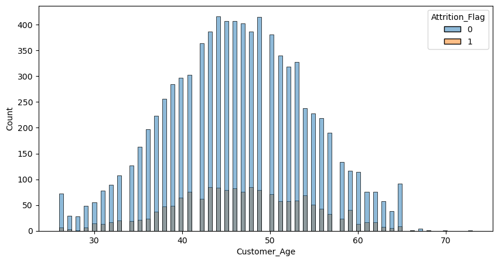

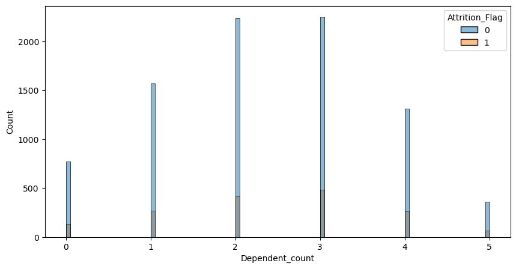

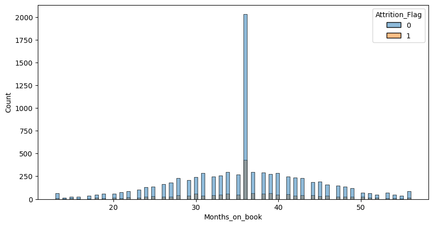

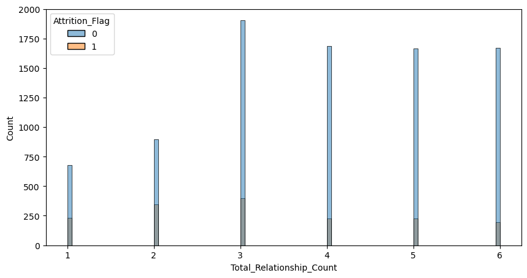

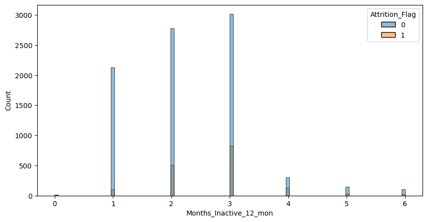

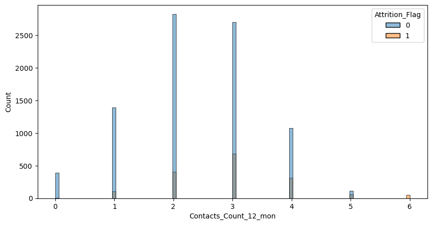

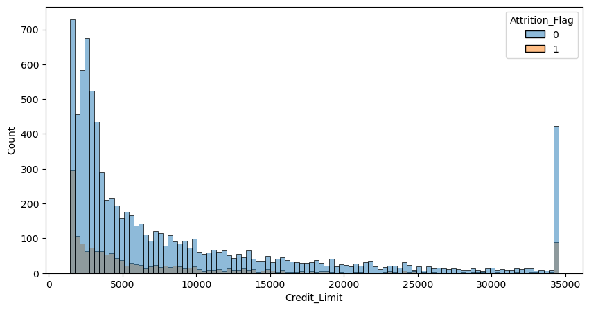

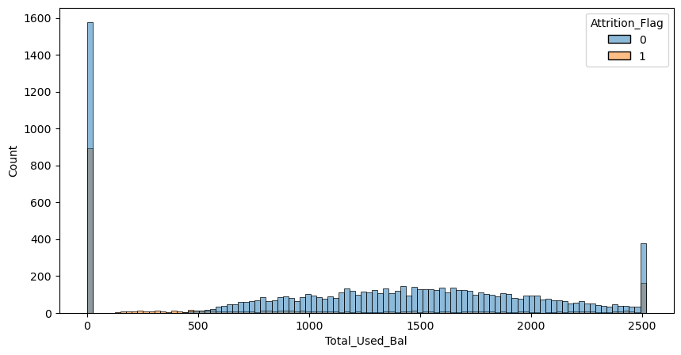

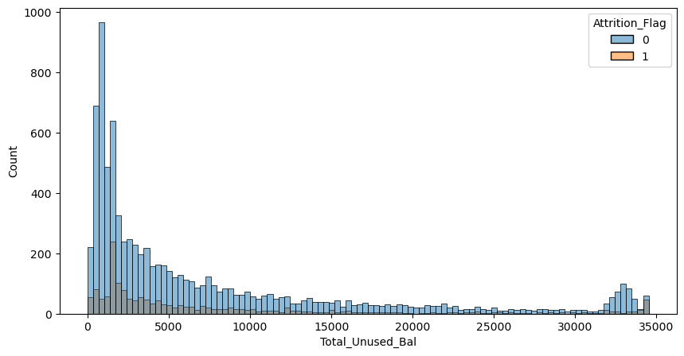

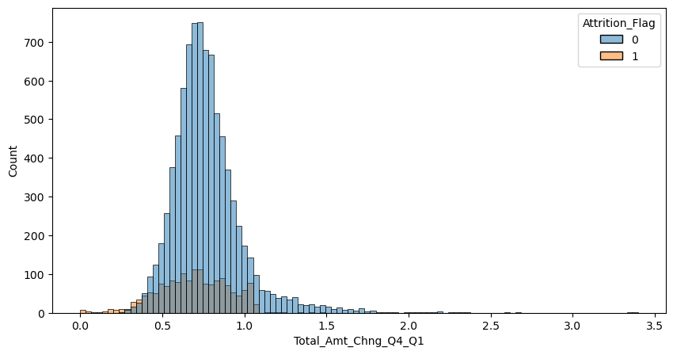

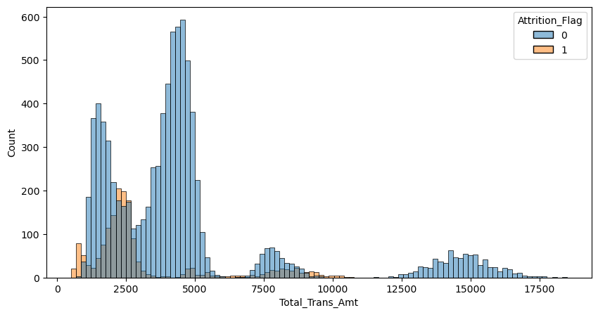

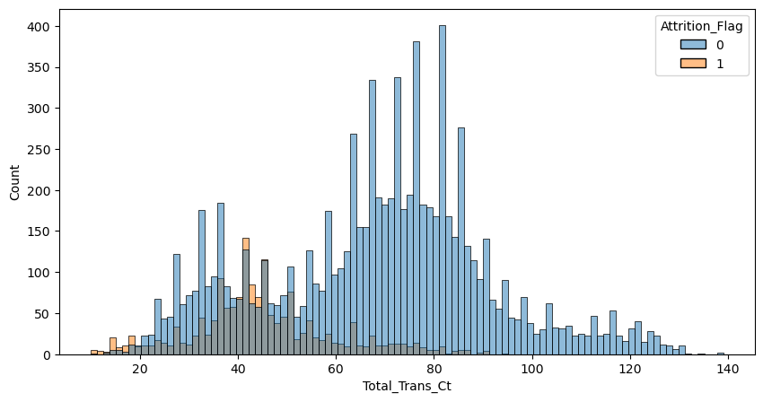

[2 more figures not shown]

```python
for col in numerical_columns:
    fig, ax = plt.subplots(figsize = (10,5))
    sns.histplot(data = data, x = col, hue = 'Attrition_Flag', bins = 100)
    plt.show()
```

#### 7) Credit Limit: Clients that have a limit of 2K dollars aprox. on the credit card are more likely to churn.

#### 8) Total Used Bal: Clients that didn't use the credit card at all are more likely to churn.

#### 9) Total Unused Bal: Clients that have a remaining of 2K dollars aprox. unused on their credit cards are more likely to churn.

b) Missing values imputation

```python
data[numerical_columns].isnull().sum()
```

```
Customer_Age                3
Dependent_count             5
Months_on_book              0
Total_Relationship_Count    0
Months_Inactive_12_mon      0
Contacts_Count_12_mon       0
Credit_Limit                0
Total_Used_Bal              0
Total_Unused_Bal            0
Total_Amt_Chng_Q4_Q1        0
Total_Trans_Amt             0
Total_Trans_Ct              0
Total_Ct_Chng_Q4_Q1         0
Avg_Utilization_Ratio       0
dtype: int64
```

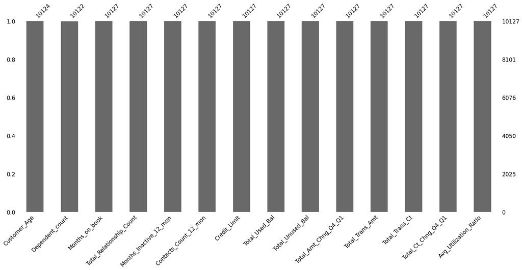

```python
msno.bar(data[numerical_columns])
```

- Customer Age

```python
data['Customer_Age']
```

```
0        45.0
1        49.0
2        51.0
3        40.0
4        40.0
         ...
10122    50.0
10123    41.0
10124    44.0
10125    30.0
10126    43.0
Name: Customer_Age, Length: 10127, dtype: float64
```

```python
data['Customer_Age'] = data['Customer_Age'].fillna(np.floor(data['Customer_Age'].mean()))
```

```python
data['Customer_Age'].isnull().sum()
```

```
0
```

- Dependent count

```python
data['Dependent_count']
```

```
0        3.0
1        5.0
2        3.0
3        4.0
4        3.0
        ...
10122    2.0
10123    2.0
10124    1.0
10125    2.0
10126    2.0
Name: Dependent_count, Length: 10127, dtype: float64
```

```python
data['Dependent_count'] = data['Dependent_count'].fillna(np.floor(data['Dependent_count'].median()))
```

```python
data['Dependent_count'].isnull().sum()
```

```
0
```

c) Feature variance

```python
data[numerical_columns].nunique()
```

```
Customer_Age                  45
Dependent_count                6
Months_on_book                44
Total_Relationship_Count       6
Months_Inactive_12_mon         7
Contacts_Count_12_mon          7
Credit_Limit                6205
Total_Used_Bal              1974
Total_Unused_Bal            6813
Total_Amt_Chng_Q4_Q1        1158
Total_Trans_Amt             5033
Total_Trans_Ct               126
Total_Ct_Chng_Q4_Q1          830
Avg_Utilization_Ratio        964
dtype: int64
```

#### Comment: No columns with unique values!

d) Outliers detection

- Credit Limit

```python
q1 = data['Credit_Limit'].quantile(0.25)
q3 = data['Credit_Limit'].quantile(0.75)
IQR = q3 - q1
lower_limit = q1 - 3 * IQR
upper_limit = q3 + 3 * IQR
```

```python
data[(data['Credit_Limit'] < lower_limit) | (data['Credit_Limit'] > upper_limit)]['Credit_Limit']
```

```
Series([], Name: Credit_Limit, dtype: float64)
```

- Months on book

```python
q1 = data['Months_on_book'].quantile(0.25)
q3 = data['Months_on_book'].quantile(0.75)
IQR = q3 - q1
lower_limit = q1 - 3 * IQR
upper_limit = q3 + 3 * IQR
```

```python
data[(data['Months_on_book'] < lower_limit) | (data['Months_on_book'] > upper_limit)]['Months_on_book']
```

```
Series([], Name: Months_on_book, dtype: int64)
```